# Measurement Redux, Summary and Midterm Evaluation

## Summary and Taking Stock

To recap: we are broadly interested in the (contextual) effect of ethnic diversity on attitudes and behavior.

We can think of Putnam’s approach as the “standard” way by which scholars have tried to tackle this question:

1. We run a survey where we ask respondents about some attitude (e.g. trust in neighbors, or anti-immigrant sentiments)
2. We also collect contextual data (e.g. perc. non-white) on the neighborhoods in which each respondent lives
3. We look for correlations between 1. and 2.

We then talked extensively in weeks 2 and 3 about why these correlations may be biased due to self-selection and the fundamental problem of causal inference.

However, self-selection (or compositional effects) may not be the only problem. A second reason bedeviling the interpretation of research results concerns the measurement of diversity itself.

## Learning Goals:

1. Explain how diversity and segregation are often **measured** in empirical research
2. Recognize Modifiable Areal Unit Problems (MAUPs) and their consequences for research on contextual effects

## Measuring Diversity

There are primarily two ways of measuring diversity in the literature: **Percent. non-White** (or percent “non-native”) and **Ethno-linguistic fractionalization (ELF)**.

**Percent. non-White** is straightforward, and also makes the most sense in situations where we are interested in the reactions of a majority group to the presence of minorities. In this case, what’s theoretical important is the binary in-group out-group distinction between people who belong to the majority population, and those who do not. Crucially, the minority is treated “monolithically” and any differences between minority groups are ignored.

**ELF** in principle measures something different. The focus is not so much on the binary in-group out-group distinction, but rather on **number** and **size** of groups in society. No special “treatment” is given to the majority group: it is simply one group amongst all others. In that sense, ELF is “color-blind.”

**ELF = 1 - ( *g<sub>1</sub>*<sup>2</sup> + *g<sub>2</sub>*<sup>2</sup> + *g<sub>3</sub>*<sup>2</sup> + … *g<sub>n</sub>*<sup>2</sup> )**, where *g<sub>n</sub>* represents the percentage of individuals from group *n* in the population.

Intuitively, this formula captures the probability that 2 individuals chosen at random from a population will belong to different ethnic groups.

**ELF Calculation: 60% white, 30% Latino, 10% black**

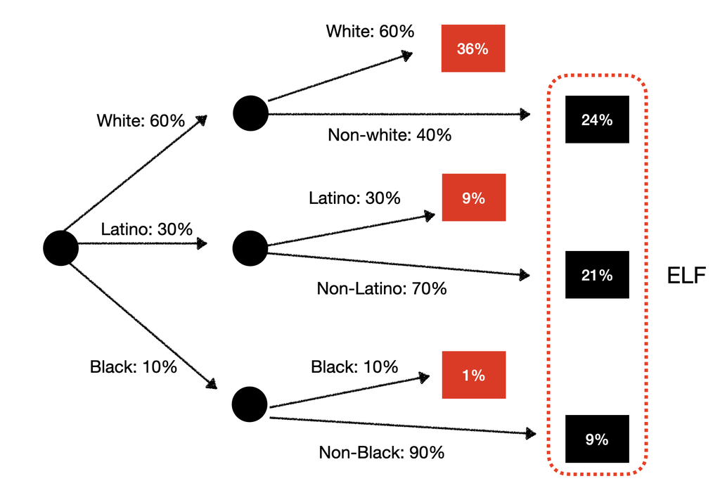

**Exercise 1**

Calculate the ELF for:

- **A:** 2 groups (0.9, 0.1)
- **B:** 2 groups (0.8, 0.2)
- **C:** 2 groups (0.5, 0.5)
- **D:** 3 groups (0.33, 0.33, 0.33)
- **E:** 4 groups (0.25, 0.25, 0.25, 0.25)
- **F:** 6 groups (0.5, 0.1, 0.1, 0.1, 0.1, 0.1)

**What do you notice when comparing:**

1. A vs. B vs. C?
2. C vs. D vs. E?
3. C vs. F?

**Exercise 2**

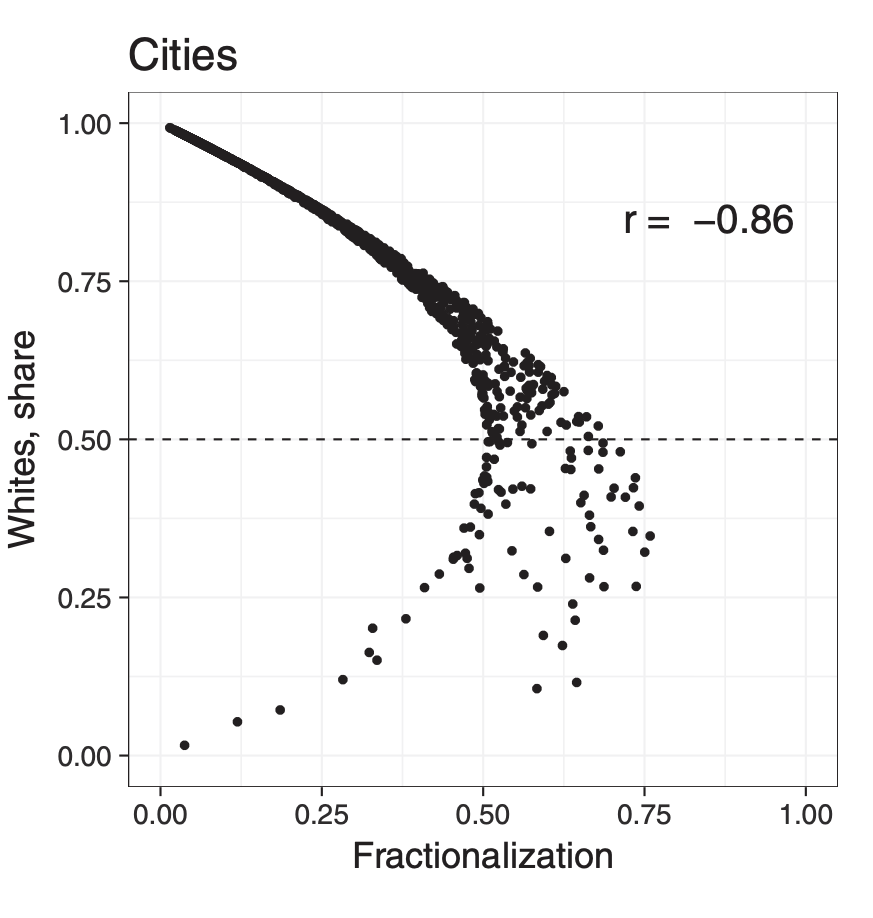

Approximately where would you locate the following cities in the graph?

- **Jackson, Mississippi:** 82% Black, 16% White, 2% Other / Mixed race
- **Portland, Maine:** 84% White, 9% Black, 4% Asian, 3% Other
- **San Francisco, California:** 41% White, 34% Asian, 15% Latino, 5% Black
- **Mobile, Alabama:** 51% Black, 44% White, 2% Mixed race, 2% Asian

**BTW:** Notice how these two measures map onto our concepts of **diversity as minority presence** vs. **diversity as heterogeneity** that we talked about last week.

## MAUPs

We mentioned two different MAUPs:

1. The problem of scale.
2. The problem of boundaries.

We also talked about the additional issue of:

3. Non-spatiality

Overall, these problems arise because measures of diversity / segregation need to be calculated over some geography. But we also don’t know (and the theory doesn’t specify) what the “correct” geography should be.

### Problem of scale

Suppose we want to compare people living in diverse vs homogenous places. Should these places be city blocks, metro areas, counties, states? The percentage of minorities that we calculate changes depending on whether one zooms in or zooms out geographically. In practice, this adds uncertainty to our estimates of the statistical relationship between the diversity of an individual’s residential context and some outcome of interest (e.g. prejudice).

**Example part 1**

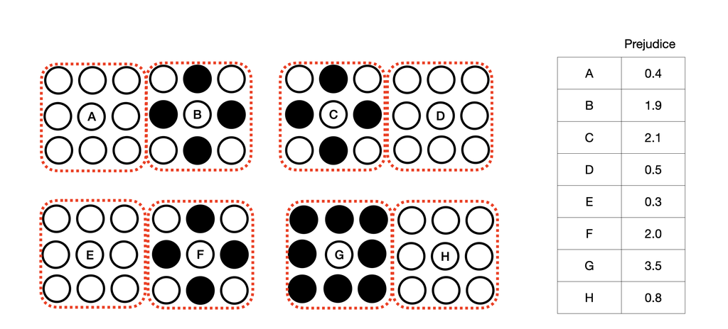

**Example part 2**

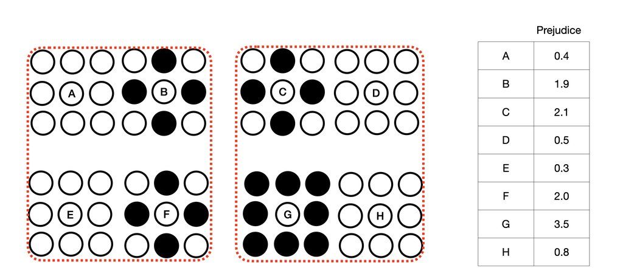

**Implications for our ability to disentangle **ELF** from **Perc. non-white**

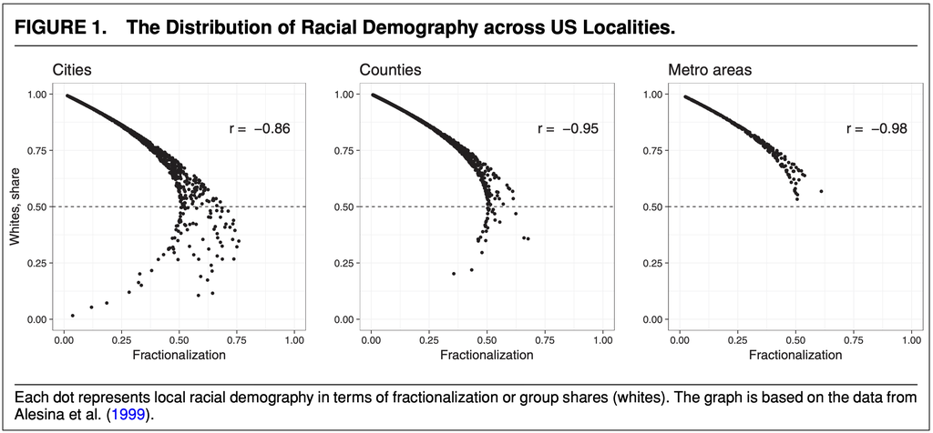

Why do observations in the lower left disappear?

**IMPORTANT:** especially at large geographic scales, we cannot statistically disentangle differences in ELF score that result (i) from an increase in non-white population vs (ii) an increase in fragmentation – that is, the number and size of minority groups. Thus it is difficult to interpret exactly what we are measuring!

### Problem of boundaries

The problem of boundaries arises because the boundaries of city blocks, metro areas, counties, etc. are often just arbitrary lines on a map. If we were to re-draw these boundaries in a different arbitrary way, our measures of diversity / segregation would change, thereby changing the statistical relationship between these quantities and our outcomes of interest. Of course, our ability to alter our estimates by simply re-drawing boundaries is problematic because the physical location of residents has remained the same – only the (arbitrary) lines have moved! In practice, this again adds uncertainty to our estimates.

**Example part 1**

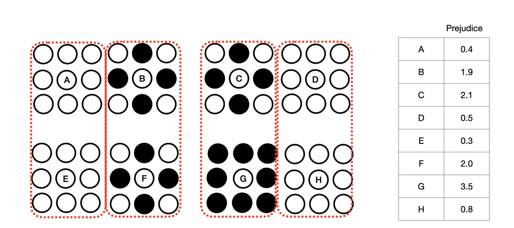

**Example part 2**

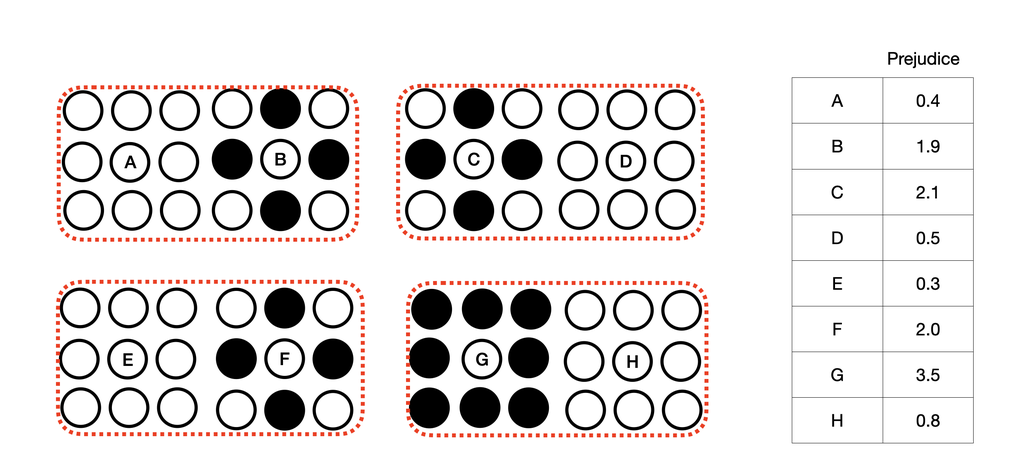

The main problem is, we don’t have any principled reason for drawing lines one way or the other. Yet we know that how we draw lines can radically change our results.

### Non-spatiality

The problem of non-spatiality refers to the fact that, for example, I can calculate how diverse a city is, but I do not know whether people from different groups live right next to each other, or whether they live very far apart.

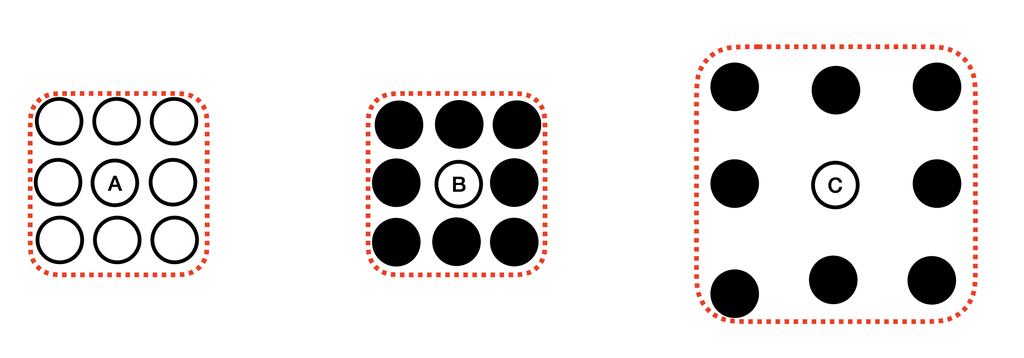

Theoretically, we might think that proximity to the outgroup matters for threat perceptions, to take just one example. But since we do not account for proximity, we are lumping together: 1. out-group + proximate = high threat 2. out-group + distant = low threat In this case, our overall estimates are an average of proximate and distant contexts.

## Further Recap

We also talked about how experiments can help us to overcome many (if not all) of these problems.

Think about Enos’ trains experiment:

- we know how to interpret the treatment
- there is no problem of MAUP
- randomization solves the problem of self-selection

Finally, in the last 2 weeks, we talked about how survey and behavioral experiments can be used to isolate the causal **mechanisms** linking diversity to negative social outcomes.

Taken together, what we have discussed so far should give you a broad toolbox of theoretical and methodological concepts for engaging with much of the ethnic diversity literature.

We will be applying these tools to some specialized topics in the remainder of the course.

**Questions?**

## Midterm evaluation

Please take a moment to fill out the [**midterm evaluation.**](https://makingdiversitywork.qualtrics.com/jfe/form/SV_0wZ804E1p337zue)